# Persuasion Words: Explore the persuasive adjectives in TED talks

# 1 Aims, objectives and background

### 1.1 Introduction

TED talks are influential videos from expert speakers who share ideas worth spreading through the speaker-audience framework. Since ancient Greece, researchers and philosophers have been interested in unlocking the art of oration. The lexical elements given in TED talks can be defined as the linguistic dictionary that plays a significant role in communication. The purpose of this report is to explore which persuasive adjectives are used by speakers in TED talk videos and to perform a sentiment analysis of the entire speech.

My project inspiration comes from a paper published in 2018 by Ebaid and others[1], which suggests that adjectives are a core element in language structure, as they are the main components for describing, identifying, and modifying nouns. Extensive use of adjectives can be a very effective persuasive tool, thereby facilitating successful speeches. Another paper also extracted persuasive adjectives from TED TALKS speeches, but I want to analyze the sentiment scores of the articles as well, while extracting these adjectives, in an attempt to draw some deeper conclusions[2].

I aim to explore which persuasive adjectives appear in different fields, such as Technology, Science, and Business, and what phenomena these adjectives reflect.

TED releases a list of the most popular talks annually, and I have decided to focus on these talks from the last decade (2014–2023) To my knowledge, there has been no similar work exploring the frequently mentioned adjectives in TED's most popular talks.

## 1.2 Aims and Objectives

Within this report, I would like to explore the following:

For this project proposal, my aims are to:

1. Determine which representative speeches are needed.
2. Determine how much data is required to sufficiently explore the research questions.
3. Collect data through web scraping . **For this phase, I used Selenium and Chrome Driver to automate tasks in the Chrome browser. To ensure the accuracy of my results and the smooth running of subsequent programs, I saved each step's output as CSV files for review. If you want to run my program, I recommend starting with the "Data Cleaning and Processing" section. To avoid the need for using Chrome Driver, I have uploaded all the scraped data to the same folder as this ipynb file. And actually, I have run each step in this file because I want to show some conclusions or organize and analyze the data after each small step. This is also why I used many print statements in the program.**
4. Clean and transform the data.
5. Conduct exploratory data analysis on the data.

## 1.3 Data

1. **Data requirements**

   The reason for choosing TED talks is that one of the basic communication skills between people is delivering rich and influential public speeches. TED talks, as a typical platform for sharing ideas, provide the audience with rich, novel, and profound content.

   Moreover, people can easily watch these talks on TED's own app, YouTube, and other platforms. The various unstructured content (such as videos, audio, and text) also provides us with abundant data resources. These data resources can be used not only for personal learning and thinking but also for academic research and data analysis.
2. **Choice of TED talks**

   I decided to choose the "Most Popular TED Talks[3]" list provided by TED for the past decade (2014–2023). These talks are evaluated based on factors such as view count, social shares, and audience feedback.

   Another choice could be "The Most Popular TED Talks of All Time[4]". I avoided choosing the "All Time" list because TED videos' view counts over the past decade might be influenced by the accumulation of time; earlier videos may have had more opportunities to be viewed due to the longer time they have been available, which could lead to an unfair comparison. Therefore, I prefer to focus on talks that have been particularly popular in recent years to better explore and understand the currently popular topics and content.

   In the word cloud analysis stage, I chose these three fields (Technology, Science, Business) because they represent the most concerned and rapidly developing areas in today's society. Talks in the technology field usually cover cutting-edge technology, innovation, and digital trends; the science field focuses on scientific exploration, discovery, and future prospects; while the business field explores market strategies and socioeconomic impacts.
3. **Data collection process**

   I manually collected the URLs of the top 10 "Most Popular TED Talks" and saved them as a CSV file. The first step was to scrape the relevant data from each URL, such as link, title, and description, for a total of 105 videos. The second step involved scraping related topics and subtitles for each talk.

   The first step took relatively little time due to the small data volume. According to the collected data, the second step took approximately 50 minutes. Given the suggested project duration of 20 hours, I believe the time spent on this process is reasonable.
4. **Challenges in collecting subtitles**

   During the collection of subtitles, I found that the web pages pointed to by the video links did not provide subtitles directly, and some adaptations to the links were necessary to obtain the subtitles. This will be reflected in the specific code.

## 1.4 Ethical Considerations

TED Talks, as a global knowledge-sharing platform, cover multiple fields such as technology, art, design, and social issues. It is renowned for its spirit of openness and public service. The core mission of TED is to spread ideas through talks, stimulate people's thinking, and promote the progress of global society. TED does not prohibit web scraping for personal non-commercial purposes in its terms of use.

To ensure compliance, I have carefully checked the robots.txt file of the TED Talks website and found no restrictions on the content needed for scraping. This means that we can use the publicly available data provided by the website for analysis and research, adhering to the principles of fair use, to explore and understand the academic insights and social perspectives contained therein.

By scraping TED Talks subtitles and conducting in-depth analysis, we can better understand and disseminate the insights and ideas included in these talks, providing valuable learning and inspiration for society.

Based on my understanding of TED's platform as one that is open and eager to share, and in adherence to the principles of fair use and legal regulations, scraping TED Talks subtitles and performing analysis is conducted within an appropriate and ethical framework.

```python
#2.1 2.2
import requests
from bs4 import BeautifulSoup
import pandas as pd

#2.3
import re

#2.4
from selenium import webdriver
from selenium.webdriver.chrome.service import Service
from selenium.webdriver.chrome.options import Options
from selenium.webdriver.common.by import By
import time

#3.2
import nltk
from nltk.tokenize import word_tokenize
nltk.download('punkt')

#3.4
import nltk
from nltk.corpus import stopwords
nltk.download('stopwords')

#3.5
# Lemmatization
from nltk.stem import WordNetLemmatizer
from nltk.corpus import wordnet
nltk.download('wordnet')
nltk.download('omw-1.4')
nltk.download('averaged_perceptron_tagger')

#4.2
!pip install pandas nltk spacy
!python -m spacy download en_core_web_sm

import spacy
nlp = spacy.load("en_core_web_sm")


#4.4
import nltk
from nltk.sentiment.vader import SentimentIntensityAnalyzer
nltk.download('vader_lexicon')

#5.1
import ast
from collections import Counter
from wordcloud import WordCloud
import matplotlib.pyplot as plt

#5.2
import matplotlib.pyplot as plt
import seaborn as sns

#5.3
from wordcloud import WordCloud
import matplotlib.pyplot as plt
```

```
     ━━━━━━━━━━━━━━━━━━━━━━━━━━━━━━━━━━━━━━━━ 12.8/12.8 MB 23.1 MB/s eta 0:00:0000:0100:01
✔ Download and installation successful
You can now load the package via spacy.load('en_core_web_sm')
```

# 2 Webscraping Articles

## 2.1 Defining Scraping and Extraction Functions

The first step is to define a function to extract the video links, titles, and description information from the CSV file containing the URLs of the "Most Popular TED Talks" for the past 10 years provided by TED.

The following code simulates the behavior of a browser, using the requests library to send HTTP requests to get the page content, and then uses the BeautifulSoup library to parse the HTML structure and extract the relevant 'a' tags to get the video links, titles, and descriptions. Finally, all the extracted data is consolidated into a Pandas DataFrame and saved as a new CSV file named url_ten_years_all_videos.csv (you can find it in the data set I submitted) for further data analysis or other processing.

```python
import requests
from bs4 import BeautifulSoup
import pandas as pd

file_path = 'url_ten_years.csv'
urls_df = pd.read_csv(file_path)

# Request headers to simulate a browser
headers = {
    'User-Agent': 'Mozilla/5.0 (Windows NT 10.0; Win64; x64) AppleWebKit/537.36 (KHTML, like Gecko) Chrome/90.0.4430.93 Safari/537.36',
    'Accept-Language': 'en-US,en;q=0.9',
    'Accept-Encoding': 'gzip, deflate, br',
    'Connection': 'keep-alive',
    'Upgrade-Insecure-Requests': '1',
    'TE': 'Trailers'
}

# Store all scraped data
all_talks = []

# Perform scraping for each URL
for url in urls_df['URL']:
    response = requests.get(url, headers=headers)
    if response.status_code == 200:
        soup = BeautifulSoup(response.content, 'html.parser')

        talks = []
        for a_tag in soup.find_all('a', class_='group block', href=True):
            link = "https://www.ted.com" + a_tag['href']

           # Find the title
            title_tag = a_tag.find('h4', class_='text-lg xl:text-2xl font-bold tracking-normal transition-colors group-hover:text-gray-700')
            title = title_tag.text.strip() if title_tag else 'No title found'

            # Find the description
            description_tag = a_tag.find('div', class_='text-sm')
            description = description_tag.text.strip() if description_tag else 'No description found'

            talks.append({'link': link, 'title': title, 'description': description})

        all_talks.extend(talks)
    else:
        # Log the failure to retrieve the page
        print(f"Failed to retrieve the page: {url}. Status code: {response.status_code}")

talks_df = pd.DataFrame(all_talks)

output_path = 'url_ten_years_all_videos.csv'
talks_df.to_csv(output_path, index=False)
print(f"Data has been saved to {output_path}")
```

```
Data has been saved to url_ten_years_all_videos.csv
```

The second step is to visit each video page from the 'url_ten_years_all_videos.csv' file and extract the related topics information from the page.

The following code uses the requests library to simulate browser behavior by sending HTTP requests to get the page content. After that, it uses the BeautifulSoup library to parse the HTML structure, locate the section containing the related topics, and consolidate them into a new DataFrame column. Finally, the updated data is saved as a new CSV file named all_videos_with_topics.csv (you can find it in the dataset I submitted).

```python
file_path = 'url_ten_years_all_videos.csv'
urls_df = pd.read_csv(file_path)

# Request headers to simulate a browser
headers = {
    'User-Agent': 'Mozilla/5.0 (Windows NT 10.0; Win64; x64) AppleWebKit/537.36 (KHTML, like Gecko) Chrome/90.0.4430.93 Safari/537.36',
    'Accept-Language': 'en-US,en;q=0.9',
    'Accept-Encoding': 'gzip, deflate, br',
    'Connection': 'keep-alive',
    'Upgrade-Insecure-Requests': '1',
    'TE': 'Trailers'
}

# Define a list to store related topics
related_topics_list = []

# Perform scraping for each URL
for url in urls_df['link']:
    response = requests.get(url, headers=headers)
    if response.status_code == 200:
        soup = BeautifulSoup(response.content, 'html.parser')

        related_topics = []
        related_topics_section = soup.find('ul', class_='mb-6 inline-block text-black')
        if related_topics_section:
            for topic_tag in related_topics_section.find_all('a', class_='inline-block py-1 text-tui-sm capitalize underline'):
                related_topics.append(topic_tag.text.strip())

        # Add related topics to the list
        related_topics_list.append(', '.join(related_topics))
    else:
        # Log the failure to retrieve the page
        print(f"Failed to retrieve the page: {url}. Status code: {response.status_code}")
        related_topics_list.append('')

# Append the related topics to the DataFrame
urls_df['Related Topics'] = related_topics_list

output_path = 'all_videos_with_topics.csv'
urls_df.to_csv(output_path, index=False)
print(f"Data has been saved to {output_path}")
```

```
Data has been saved to all_videos_with_topics.csv
```

## 2.3 Extracting Year Data

```python
import re

file_path = 'all_videos_with_topics.csv'
df = pd.read_csv(file_path)

# Function to extract year from link
def extract_year(link):
    match = re.search(r'(\d{4})', link)
    return match.group(0) if match else None

# Apply the function to the 'link' column and create a new 'Year' column
df['Year'] = df['link'].apply(extract_year)

# Save the updated DataFrame to a new CSV file
output_file_path = 'all_videos_with_topics_and_year.csv'
df.to_csv(output_file_path, index=False)

print("year OK")
print(f"Data has been saved to {output_file_path}")
```

```
year OK
Data has been saved to all_videos_with_topics_and_year.csv
```

## 2.4 Extracting Subtitles for Each Video

The third step is to modify the link format for each video from 'all_videos_with_topics_and_year.csv', add subtitle parameters to form new links, and scrape the subtitle text data.

The following code uses Selenium and Chrome WebDriver. The subtitles of each video are combined into a single string and stored in a new column called 'subtitles'. Intermediate results are saved every 10 videos to prevent data loss due to network interruptions or long operations. This strategy ensures that part of the processed data is retained even during long-running processes.

Finally, all data is saved as 'ted_talks_with_subtitles.csv' (you can find it in the dataset I submitted).

```python
import pandas as pd
from selenium import webdriver
from selenium.webdriver.chrome.service import Service
from selenium.webdriver.chrome.options import Options
from selenium.webdriver.common.by import By
import time

csv_file_path = 'all_videos_with_topics_and_year.csv'
df = pd.read_csv(csv_file_path)

# Set up WebDriver
service = Service(executable_path="/Users/2shihua1yin/Downloads/chromedriver-mac-x64/chromedriver")
chrome_options = Options()
chrome_options.add_argument('--headless')
driver = webdriver.Chrome(service=service, options=chrome_options)

# Add a new column to store subtitles
df['subtitles'] = ''

count = 0

# Iterate over all URLs in the CSV file
for index, row in df.iterrows():
    url = row['link'].replace("?referrer=", "/transcript?referrer=") + "&subtitle=en"
    driver.get(url)

    # Wait for the page to load
    time.sleep(5)

    subtitles = driver.find_elements(By.CSS_SELECTOR, 'div[data-testid="paragraphs-container"] div[role="button"] span[dir="ltr"]')

    subtitle_text = ' '.join([subtitle.text.strip() for subtitle in subtitles])
    df.at[index, 'subtitles'] = subtitle_text

    # Print progress
    count += 1
    print(f"Processed {count}/{len(df)}: {url}")

    # Save every 10 scraped subtitles
    if count % 10 == 0:
        temp_csv_file_path = f'ted_talks_with_subtitles_part_{count//10}.csv'
        df.iloc[:count].to_csv(temp_csv_file_path, index=False)
        print(f"Intermediate CSV file saved to: {temp_csv_file_path}")

# Close the browser
driver.quit()

final_csv_file_path = 'ted_talks_with_subtitles.csv'
df.to_csv(final_csv_file_path, index=False)

print(f"Final CSV file saved to: {final_csv_file_path}")
```

## Conclusion of Data Collection

At this point, the data collection work is complete. In the ted_talks_with_subtitles.csv file, the following information is included:

- Video link
- Title and description
- Related topics
- Year
- Subtitles

## 3 Data Cleaning and Processing

### 3.1 Data Cleansing and NaN Handling

The following code first reads the specified CSV file and checks for NaN values in the 'subtitles' field. If NaN values are found, it prints example rows and removes these rows from the DataFrame. Finally, the code rechecks the entire DataFrame for any remaining NaN values and outputs the names of any columns that still contain NaN values to ensure thoroughness and reliability in data processing.

```python
import pandas as pd

file_path = 'ted_talks_with_subtitles.csv'

dataframe = pd.read_csv(file_path)

# Check the number of NaN values in the 'subtitles' field
nan_count = dataframe['subtitles'].isna().sum()
print("Number of NaN values in 'subtitles' field:", nan_count)

#view the specific rows containing NaN
if nan_count > 0:
    print("Rows containing NaN:")
    print(dataframe[dataframe['subtitles'].isna()])

# Remove rows containing NaN
dataframe.dropna(subset=['subtitles'], inplace=True)

# Check if the entire DataFrame still contains any NaN values after processing
if dataframe.isna().any().any():
    print("There are still NaN values in the DataFrame.")
    print("Columns containing NaN values are:")
    print(dataframe.columns[dataframe.isna().any()].tolist())
else:
    print("All NaN values have been handled, and there are no NaN values left in the DataFrame.")
```

```
Number of NaN values in 'subtitles' field: 2
Rows containing NaN:
                                                 link  \
4   https://www.ted.com/talks/terry_moore_a_myster...
56  https://www.ted.com/talks/lera_boroditsky_how_...

                                                title  \
4   A mysterious design that appears across millennia
56               How language shapes the way we think

                                          description  \
4   What can we make of a design that shows up ove...
56  There are about 7,000 languages spoken around ...

                                       Related Topics  Year subtitles
4             culture, design, art, history, humanity  2023       NaN
56  science, cognitive science, communication, lan...  2018       NaN
All NaN values have been handled, and there are no NaN values left in the DataFrame.
```

**There are two data entries with empty subtitles, so I deleted these two entries to ensure the remaining data is valid.**

### 3.2 Tokenization of TED Talks Subtitles Using NLTK

The following code uses the word_tokenize function from the NLTK library to tokenize the 'subtitles' column. The purpose of this is to convert the subtitle text into a sequence of words or punctuation marks for further natural language processing or text analysis.

```python
import nltk
from nltk.tokenize import word_tokenize
nltk.download('punkt')

# Tokenize the 'subtitles' column
dataframe['tokenized_subtitles'] = dataframe['subtitles'].apply(word_tokenize)

# Display the first few rows of the processed data to confirm tokenization has been done correctly
print("First few rows of the data after tokenization:")
print(dataframe[['subtitles', 'tokenized_subtitles']].head())
```

```
First few rows of the data after tokenization:
                                           subtitles  \
0  I have a big question. Which is, who runs the ...
1  So, I'm from Guatemala. This is a public servi...
2  We started OpenAI seven years ago because we f...
3  I spent 22 incredible years at Apple, helping ...
5  So anyone who's been paying attention for the ...

                                 tokenized_subtitles
0  [I, have, a, big, question, ., Which, is, ,, w...
1  [So, ,, I, 'm, from, Guatemala, ., This, is, a...
2  [We, started, OpenAI, seven, years, ago, becau...
3  [I, spent, 22, incredible, years, at, Apple, ,...
5  [So, anyone, who, 's, been, paying, attention,...
```

**Comparing 'subtitles' and 'tokenized_subtitles', it can be seen that the subtitles have been divided into individual words.**

### 3.2 Removing Punctuation

The following code further cleans the tokenized subtitle data by defining the remove_punctuation function, which removes all non-alphabetic characters.

```python
# Define a function to remove punctuation
def remove_punctuation(words):
    new_words = [word for word in words if word.isalpha()]
    return new_words

# Apply the function to remove punctuation
dataframe['tokenized_subtitles'] = dataframe['tokenized_subtitles'].apply(remove_punctuation)

print("First few rows of the data after removing punctuation:")
print(dataframe[['tokenized_subtitles']].head())
```

```
First few rows of the data after removing punctuation:
                                 tokenized_subtitles
0  [I, have, a, big, question, Which, is, who, ru...
1  [So, I, from, Guatemala, This, is, a, public, ...
2  [We, started, OpenAI, seven, years, ago, becau...
3  [I, spent, incredible, years, at, Apple, helpi...
5  [So, anyone, who, been, paying, attention, for...
```

**It can be seen that the punctuation marks have been removed.**

### 3.3 Word Count Verification of Tokenized TED Talks Subtitles

The following code performs word count and analysis on the video subtitle data. First, it calculates the word count for each row in the 'tokenized_subtitles' column. Then, it computes the maximum, minimum, and average values of 'word_count', and retrieves and prints the links and titles of the rows with the maximum and minimum word counts so that I can directly click the links for verification. Finally, the updated DataFrame is exported as ted_talks_with_subtitles_words_count.csv (you can find it in the dataset I submitted).

```python
# Count the number of words in each row of 'tokenized_subtitles'
dataframe['word_count'] = dataframe['tokenized_subtitles'].apply(len)

# Calculate the maximum, minimum, and average values of 'word_count'
max_word_count = dataframe['word_count'].max()
min_word_count = dataframe['word_count'].min()
mean_word_count = dataframe['word_count'].mean()

# Get the rows with the maximum and minimum word counts
max_word_count_row = dataframe[dataframe['word_count'] == max_word_count].iloc[0]
min_word_count_row = dataframe[dataframe['word_count'] == min_word_count].iloc[0]

print(f"Maximum 'word_count': {max_word_count}, link: {max_word_count_row['link']}, title: {max_word_count_row['title']}")
print(f"Minimum 'word_count': {min_word_count}, link: {min_word_count_row['link']}, title: {min_word_count_row['title']}")
print(f"Average 'word_count': {mean_word_count}")

output_file_path = 'ted_talks_with_subtitles_words_count.csv'
dataframe.to_csv(output_file_path, index=False)

print(f"The DataFrame has been exported to {output_file_path}")
```

```
Maximum 'word_count': 10712, link: https://www.ted.com/talks/elizabeth_gilbert_it_s_ok_to_feel_overwhelmed_here_s_what_to_do_next?referrer=playlist-the_most_popular_talks_of_2020&autoplay=true, title: It's OK to feel overwhelmed. Here's what to do next
Minimum 'word_count': 510, link: https://www.ted.com/talks/burcin_mutlu_pakdil_a_rare_galaxy_that_s_challenging_our_understanding_of_the_universe?referrer=playlist-the_most_popular_ted_talks_of_2018&autoplay=true, title: A rare galaxy that's challenging our understanding of the universe
Average 'word_count': 2337.621359223301
The DataFrame has been exported to ted_talks_with_subtitles_words_count.csv
```

#### Validation of Statistical Results

#### Maximum Word Count

The talk with the highest word count is "It's OK to feel overwhelmed. Here's what to do next," with a word count of 10,712 and a duration of 1:02:06. This talk discusses the emotions of anxiety, loneliness, and grief brought by the current pandemic, emphasizing the importance of compassion, self-care, and maintaining creativity and hope during crises.

#### Minimum Word Count

The talk with the lowest word count is "A rare galaxy that's challenging our understanding of the universe," with a word count of 510 and a duration of 04:29. This talk describes a newly discovered extremely rare galaxy "Burçin's Galaxy," which has a unique dual-ring structure that challenges existing theories of galaxy formation and evolution. The talk is concise and focused on a single scientific discovery, making it the talk with the fewest words in the statistics.

#### Average Word Count

The talk closest to the average word count (2,337) is "How to stop languishing and start finding flow," with a word count of 2,399 and a duration of approximately 16 minutes.

### 3.4 Removing Stop Words

The following code further cleans and optimizes the data by removing stop words from the subtitles. The purpose of this is to improve data quality and provide more meaningful data for subsequent natural language processing and text analysis.

```python
import nltk
from nltk.corpus import stopwords
nltk.download('stopwords')
# Get English stop words
stop_words = set(stopwords.words('english'))

# Define a function to remove stop words
def remove_stopwords(words):
    new_words = [word for word in words if word.lower() not in stop_words]
    return new_words

dataframe['subtitles_without_stopwords'] = dataframe['tokenized_subtitles'].apply(remove_stopwords)

# Display the first few rows of the processed data to confirm stop words have been removed correctly
print("First few rows of the data after removing stop words:")
print(dataframe[['tokenized_subtitles', 'subtitles_without_stopwords']].head(3))
```

```
First few rows of the data after removing stop words:
                                 tokenized_subtitles  \
0  [I, have, a, big, question, Which, is, who, ru...
1  [So, I, from, Guatemala, This, is, a, public, ...
2  [We, started, OpenAI, seven, years, ago, becau...

                         subtitles_without_stopwords
0  [big, question, runs, world, used, easy, quest...
1  [Guatemala, public, service, announcement, Gua...
2  [started, OpenAI, seven, years, ago, felt, lik...
```

**By comparing 'tokenized_subtitles' and 'subtitles_without_stopwords', you can see that Stop Words have been removed.**

### 3.5 Lemmatization

The following code performs lemmatization on the video subtitles. The specific steps include defining functions to get part-of-speech tags and lemmatize the words, applying lemmatization to the list of words after removing stop words, and storing the results in a new column called 'lemmatized_subtitles'.

```python
# Lemmatization
from nltk.stem import WordNetLemmatizer
from nltk.corpus import wordnet
nltk.download('wordnet')
nltk.download('omw-1.4')
nltk.download('averaged_perceptron_tagger')

lemmatizer = WordNetLemmatizer()

# Define a function to get WordNet part-of-speech tags
def get_wordnet_pos(word):
    tag = nltk.pos_tag([word])[0][1][0].upper()
    tag_dict = {"J": wordnet.ADJ,
                "N": wordnet.NOUN,
                "V": wordnet.VERB,
                "R": wordnet.ADV}
    return tag_dict.get(tag, wordnet.NOUN)

# Define a function for lemmatization
def lemmatize_words(words):
    new_words = [lemmatizer.lemmatize(word, get_wordnet_pos(word)) for word in words]
    return new_words


dataframe['lemmatized_subtitles'] = dataframe['subtitles_without_stopwords'].apply(lemmatize_words)

# Display the first few rows of the processed data to confirm lemmatization has been done correctly
print("First few rows of the data after lemmatization:")
print(dataframe[['subtitles_without_stopwords', 'lemmatized_subtitles']].head(4))
```

```
First few rows of the data after lemmatization:
                         subtitles_without_stopwords  \
0  [big, question, runs, world, used, easy, quest...
1  [Guatemala, public, service, announcement, Gua...
2  [started, OpenAI, seven, years, ago, felt, lik...
3  [spent, incredible, years, Apple, helping, des...

                                lemmatized_subtitles
0  [big, question, run, world, use, easy, questio...
1  [Guatemala, public, service, announcement, Gua...
2  [start, OpenAI, seven, year, ago, felt, like, ...
3  [spent, incredible, year, Apple, help, design,...
```

**Lemmatization reduces word forms to their base or root form, improving the consistency and analyzability of the data. You can see from the few rows printed that "runs" is lemmatized to "run," and "used" is lemmatized to "use."**

```python
# The above data processing is complete, export it as a new CSV
output_path = 'ted_talks_with_lemmatized_subtitles.csv'
dataframe.to_csv(output_path, index=False, encoding='utf-8-sig')

print(f"The lemmatized data has been saved as {output_path}")
```

```
The lemmatized data has been saved as ted_talks_with_lemmatized_subtitles.csv
```

## Conclusion of Data Cleaning and Processing

At this point, the data cleaning and processing part is complete. The data will be exported as a new file named ted_talks_with_lemmatized_subtitles.csv(you can find it in the dataset I submitted).

## 4 Generating Features

In this section, the feature generation process begins. We need to read the ted_talks_with_lemmatized_subtitles.csv file again and create a new DataFrame named new_dataframe.

Next, we count the total number of records in new_dataframe. The result here is 103 records, because 2 records were removed in the NaN handling part. After checking the data, no issues were found, so I will continue with the analysis.

```python
import pandas as pd
new_dataframe = pd.read_csv(output_path, encoding='utf-8-sig')

total_count = len(new_dataframe)
print(f'Total number of TED talks: {total_count}')

shape = new_dataframe.shape
print(f'Shape of the DataFrame: {shape}')

columns = new_dataframe.columns
print(f'Columns in the DataFrame: {columns}')
```

```
Total number of TED talks: 103
Shape of the DataFrame: (103, 10)
Columns in the DataFrame: Index(['link', 'title', 'description', 'Related Topics', 'Year', 'subtitles',
       'tokenized_subtitles', 'word_count', 'subtitles_without_stopwords',
       'lemmatized_subtitles'],
      dtype='object')
```

### 4.1 Classifying and Merging Subtitles of TED Talks by Category

The following code classifies the subtitles of TED Talks into 'technology', 'science', 'business', or 'other' based on the 'Related Topics' column by defining a classification function. Then, it merges the word lists in the 'lemmatized_subtitles' column for each category to generate a new DataFrame named merged_df.

```python
# Create a new column to store classification information
def classify_topic(topics):
    if 'technology' in topics.lower():
        return 'technology'
    elif 'science' in topics.lower():
        return 'science'
    elif 'business' in topics.lower():
        return 'business'
    else:
        return 'other'

new_dataframe['category'] = new_dataframe['Related Topics'].apply(classify_topic)

# Filter the data for the three categories
technology_df = new_dataframe[new_dataframe['category'] == 'technology']
science_df = new_dataframe[new_dataframe['category'] == 'science']
business_df = new_dataframe[new_dataframe['category'] == 'business']

# Merge the lemmatized_subtitles column
technology_lemmas = technology_df['lemmatized_subtitles'].sum()
science_lemmas = science_df['lemmatized_subtitles'].sum()
business_lemmas = business_df['lemmatized_subtitles'].sum()

# Create a new DataFrame to store the merged data
merged_df = pd.DataFrame({
    'category': ['technology', 'science', 'business'],
    'lemmatized_subtitles': [technology_lemmas, science_lemmas, business_lemmas]
})

# Display the processed data to confirm the merging was done correctly
print("Merged data:")
print(merged_df)
```

```
Merged data:
     category                               lemmatized_subtitles
0  technology  ['big', 'question', 'run', 'world', 'use', 'ea...
1     science  ['know', 'lot', 'harder', 'seem', 'like', 'Act...
2    business  ['Naomi', 'Bagdonas', 'Alright', 'often', 'lau...
```

### 4.2 Extracting Adjectives

The following code uses the spaCy library to extract adjectives from the merged subtitle data.

Specifically, it defines a function to extract adjectives, then iterates through the subtitle data for each category ('technology', 'science', 'business'), extracts the adjectives, and stores the results in a new DataFrame named adjectives_df.

```python
!pip install pandas nltk spacy
!python -m spacy download en_core_web_sm
```

```python
import spacy
nlp = spacy.load("en_core_web_sm")

def extract_adjectives(text):
    doc = nlp(text)
    adjectives = [token.text for token in doc if token.pos_ == 'ADJ']
    return adjectives

# Extract adjectives from each category
adjectives_data = []
for index, row in merged_df.iterrows():
    adjectives = extract_adjectives(row['lemmatized_subtitles'])
    adjectives_data.append({'category': row['category'], 'adjectives': adjectives})


# Extract adjectives from each category
technology_adjectives = extract_adjectives(technology_lemmas)
science_adjectives = extract_adjectives(science_lemmas)
business_adjectives = extract_adjectives(business_lemmas)

# Create a new DataFrame to store the adjectives data
adjectives_df = pd.DataFrame(adjectives_data)

# Display the adjectives data to confirm extraction was done correctly
print("Extracted adjectives:")
print(adjectives_df)
```

```
Extracted adjectives:
     category                                         adjectives
0  technology  [big, easy, bipolar, simple, global, raw, unip...
1     science  [harder, alive, least, busy, languish, little,...
2    business  [personal, favorite, teachable, underappreciat...
```

### 4.3 Identifying and Extracting Unique Adjectives

The following code extracts unique adjectives for each category ('technology', 'science', 'business') from the TED Talks subtitle data:

1. Identifies adjectives common to all three categories.
2. Removes these common adjectives to retain only unique adjectives for each category.
3. Creates a new DataFrame to store these unique adjectives and saves the result as a CSV file named filtered_adjectives.csv.

```python
# Find common adjectives in all three categories
common_adjectives = set(technology_adjectives) & set(science_adjectives) & set(business_adjectives)

# Remove common adjectives from each category
technology_unique_adjectives = [adj for adj in technology_adjectives if adj not in common_adjectives]
science_unique_adjectives = [adj for adj in science_adjectives if adj not in common_adjectives]
business_unique_adjectives = [adj for adj in business_adjectives if adj not in common_adjectives]

# Create a new DataFrame to store the adjectives data
filtered_adjectives_df = pd.DataFrame({
    'category': ['technology', 'science', 'business'],
    'filtered_adjectives': [technology_unique_adjectives, science_unique_adjectives, business_unique_adjectives]
})

# Print the remaining adjectives in each category
print("Remaining adjectives in each category:")
print(filtered_adjectives_df[['category', 'filtered_adjectives']])

filtered_adjectives_df.to_csv('filtered_adjectives.csv', index=False, encoding='utf-8')
print("Data saved as filtered_adjectives.csv")
```

```
Remaining adjectives in each category:
     category                                filtered_adjectives
0  technology  [bipolar, raw, unipolar, Western, former, angr...
1     science  [languish, plenty, enjoyable, sloppy, dictiona...
2    business  [teachable, underappreciated, behavioral, corp...
Data saved as filtered_adjectives.csv
```

### 4.4 Sentiment Analysis

The following code uses the VADER sentiment analysis tool to perform sentiment analysis on the subtitle data of each video, extracting negative, neutral, positive, and compound sentiment scores. The analysis results are then stored in a new CSV file named final.csv (you can find it in the dataset I submitted) for use in the fifth section of the analysis.

```python
import nltk
from nltk.sentiment.vader import SentimentIntensityAnalyzer
nltk.download('vader_lexicon')

# Creating an instance of the VADER sentiment analyzer
analyzer = SentimentIntensityAnalyzer()

# Defining the sentiment analysis function
def sentiment_analysis(text):
    sentiment_scores = analyzer.polarity_scores(text)
    return sentiment_scores['neg'], sentiment_scores['neu'], sentiment_scores['pos'], sentiment_scores['compound']

# Performing sentiment analysis on subtitles of each talk and storing the results in new columns
new_dataframe[['neg_sentiment', 'neu_sentiment', 'pos_sentiment', 'compound_sentiment']] = new_dataframe['subtitles'].apply(lambda x: pd.Series(sentiment_analysis(x)))


new_dataframe.to_csv('final.csv', index=False, encoding='utf-8')
print("Data saved as final.csv")
```

```
Data saved as final.csv
```

## 5 Exploratory Data Analysis

In this section, I will read the final CSV file exported from the fourth section and create a new DataFrame named final_df. By printing the attributes of the DataFrame, I can confirm that there are no issues with the data and proceed with the analysis.

```python
import pandas as pd

file_path = 'final.csv'
final_df = pd.read_csv(file_path)

# Display the shape of the DataFrame (number of rows and columns)
print(f"Shape of the DataFrame: {final_df.shape}")

# Display the column names of the DataFrame
print("Column names of the DataFrame:")
print(final_df.columns)

# Display descriptive statistics of the sentiment analysis results
print("Descriptive statistics of the sentiment analysis results:")
print(final_df[['neg_sentiment', 'neu_sentiment', 'pos_sentiment', 'compound_sentiment']].describe())
```

```
Shape of the DataFrame: (103, 15)
Column names of the DataFrame:
Index(['link', 'title', 'description', 'Related Topics', 'Year', 'subtitles',
       'tokenized_subtitles', 'word_count', 'subtitles_without_stopwords',
       'lemmatized_subtitles', 'category', 'neg_sentiment', 'neu_sentiment',
       'pos_sentiment', 'compound_sentiment'],
      dtype='object')
Descriptive statistics of the sentiment analysis results:
       neg_sentiment  neu_sentiment  pos_sentiment  compound_sentiment
count     103.000000     103.000000     103.000000          103.000000
mean        0.073748       0.784447       0.141728            0.770831
std         0.034911       0.046065       0.038659            0.610848
min         0.012000       0.627000       0.041000           -0.999700
25%         0.048500       0.749000       0.117500            0.997050
50%         0.071000       0.787000       0.139000            0.999500
75%         0.093500       0.819000       0.167000            0.999800
max         0.174000       0.899000       0.280000            1.000000
```

### 5.1 Generating a Word Cloud of the Most Common Words in TED Talks Subtitles

The following code combines the words in the 'lemmatized_subtitles' column of all TED Talks into a single list, uses Counter to count the word frequencies, and generates a word cloud based on the frequencies.

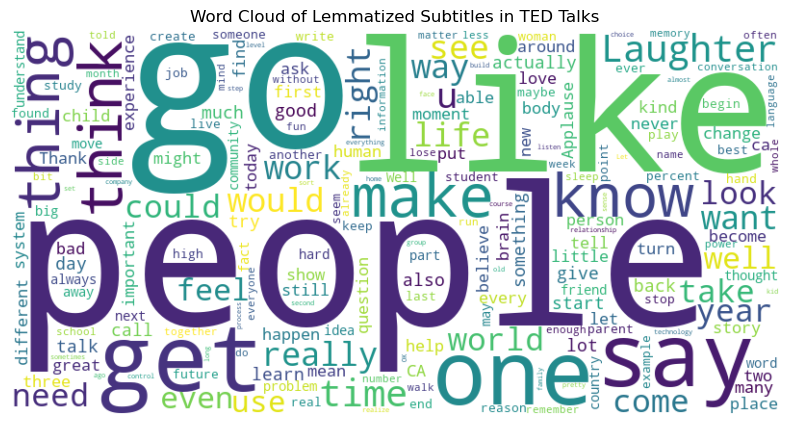

```python
import ast
from collections import Counter
from wordcloud import WordCloud
import matplotlib.pyplot as plt
all_words = [word for sublist in final_df['lemmatized_subtitles'].dropna().apply(ast.literal_eval) for word in sublist]

# Count word frequencies using Counter
word_counts = Counter(all_words)

# Generate the word cloud
wordcloud = WordCloud(width=800, height=400, background_color='white').generate_from_frequencies(word_counts)

# Display the word cloud using matplotlib
plt.figure(figsize=(10, 5))
plt.imshow(wordcloud, interpolation='bilinear')
plt.axis('off')
plt.title('Word Cloud of Lemmatized Subtitles in TED Talks')
plt.show()
```

### Summary

These high-frequency words reflect the common themes and styles in TED talks. Speakers tend to explore important topics such as interpersonal relationships (e.g., "people"), actions and changes (e.g., "go", "get"), and time and life (e.g., "time", "life"). This reveals that TED talks emphasize practical action, personal growth, and social interaction.

### 5.2 Subtitle Length Distribution

The following code extracts the word count of each subtitle and uses the matplotlib and seaborn libraries to plot a histogram, showing the distribution of subtitle lengths.

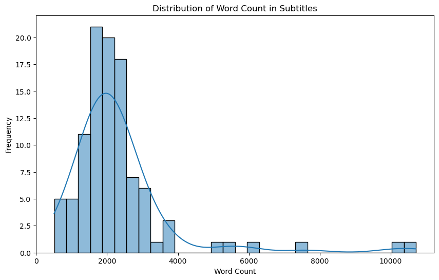

```python
import matplotlib.pyplot as plt
import seaborn as sns

word_counts = final_df['word_count']

max_count = word_counts.max()
min_count = word_counts.min()
mean_count = word_counts.mean()
median_count = word_counts.median()


plt.figure(figsize=(10, 6))
sns.histplot(word_counts, bins=30, kde=True)
plt.title('Distribution of Word Count in Subtitles')
plt.xlabel('Word Count')
plt.ylabel('Frequency')
plt.show()
```

### Conclusion

This section is a visualization of the word count from section 3.3. It is evident that the majority of the talks have a length of around 2050 words, corresponding to a duration of approximately 15 minutes.

### 5.3 Generating Word Clouds for Adjectives in Technology, Science, and Business Categories

The purpose of this code is to generate and display word clouds for adjectives in the technology, science, and business categories. First, we need to define a function to generate a word cloud from a list of adjectives, and then use matplotlib to display it.

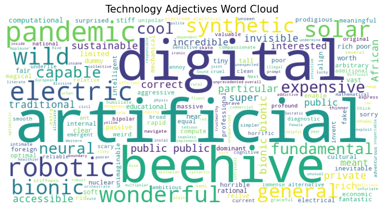

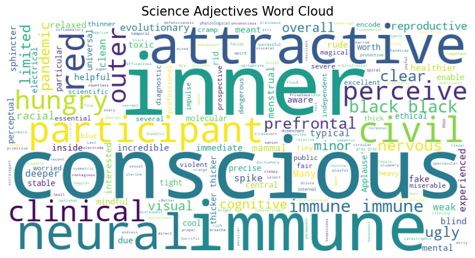

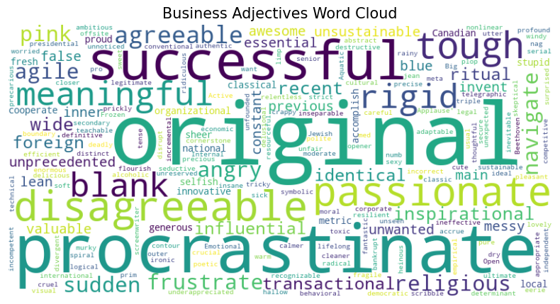

```python
from wordcloud import WordCloud
import matplotlib.pyplot as plt

def generate_wordcloud(text, title):
    wordcloud = WordCloud(width=800, height=400, background_color='white').generate(' '.join(text))
    plt.figure(figsize=(10, 5))
    plt.imshow(wordcloud, interpolation='bilinear')
    plt.title(title, fontsize=15)
    plt.axis('off')
    plt.show()


generate_wordcloud(technology_unique_adjectives, 'Technology Adjectives Word Cloud')
generate_wordcloud(science_unique_adjectives, 'Science Adjectives Word Cloud')
generate_wordcloud(business_unique_adjectives, 'Business Adjectives Word Cloud')
```

### Conclusion

1. **Technology Category**: In the technology category, adjectives are often related to future technology, intelligence, and modernization. For example, words like “bionic”, “artificial”, “robotic”, and “electric” frequently appear, reflecting the focus on technological advancement and innovation. Additionally, words like “digital” and “neural” highlight the emphasis on information technology and neural networks.
2. **Science Category**: The science category often involves terms related to biology, health, and psychology. Words such as “immune”, “conscious”and “clinical” are frequently mentioned, indicating a focus on health, mental states, and related scientific research.
3. **Business Category**: In the business category, adjectives are more related to innovation, success, and emotions. Words like “original”, “successful”, “passionate”, and “meaningful” are common, reflecting the emphasis on innovation, success, and emotional expression. The appearance of words like “procrastinate” and “frustrate” may reflect concerns about time management and emotional handling in the business field.

Overall, frequently appearing adjectives in each category tend to be positive in nature. For instance, “wonderful” in technology, “clear” in science, and “inspirational” in business convey positive emotions and expectations for progress and positive change.

```python
# `filtered_adjectives_df` is the DataFrame of unique adjectives in the three categories, and `final_df` is the complete DataFrame.
```

### 5.4 Visualizing Mean Sentiment Scores by Category

The following code calculates and visualizes the mean sentiment scores for different categories, showing the negative, neutral, positive, and compound sentiment scores for each category:

1. Group by category and calculate the mean of these sentiment scores.
2. Plot a heatmap to display the results.

```
     category  neg_sentiment  neu_sentiment  pos_sentiment  compound_sentiment
0    business       0.065875       0.761875       0.172375            0.999413
1     science       0.069000       0.798278       0.132556            0.743183
2  technology       0.050105       0.816158       0.133632            0.893979
```

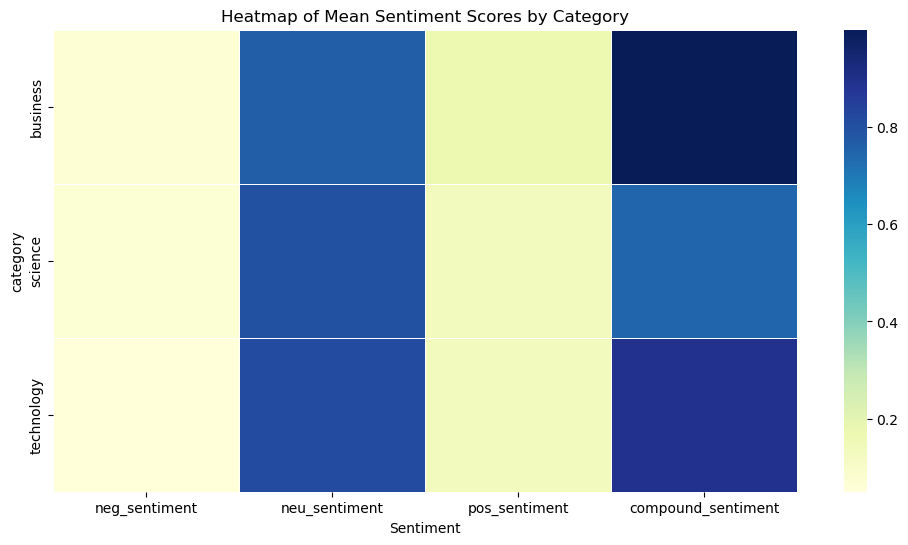

```python
# Create a new DataFrame excluding the 'other' category
filtered_other_df = final_df[final_df['category'] != 'other']

# Group by category and calculate the mean sentiment scores
sentiment_means = filtered_other_df.groupby('category').agg({
    'neg_sentiment': 'mean',
    'neu_sentiment': 'mean',
    'pos_sentiment': 'mean',
    'compound_sentiment': 'mean'
}).reset_index()

# Display the results
print(sentiment_means)

# Prepare data for the heatmap
heatmap_data = sentiment_means.melt(id_vars='category', var_name='Sentiment', value_name='Score')
heatmap_data_pivot = heatmap_data.pivot(index='category', columns='Sentiment', values='Score')

# Ensure all categories and sentiments are present
heatmap_data_pivot = heatmap_data_pivot.reindex(columns=['neg_sentiment', 'neu_sentiment', 'pos_sentiment', 'compound_sentiment'])

# Plot the heatmap
plt.figure(figsize=(12, 6))
sns.heatmap(heatmap_data_pivot, annot=False, cmap="YlGnBu", cbar=True, linewidths=.5)
plt.title('Heatmap of Mean Sentiment Scores by Category')
plt.show()
```

### Conclusion

Based on the above charts and data, we can draw some deeper conclusions:

1. **Business Category**: Business talks exhibit significant positivity and motivational content. The highest positive and compound sentiment scores reflect that these talks aim to inspire innovation, encourage entrepreneurship, and showcase success stories, thereby evoking positive emotions and actions from the audience.
2. **Science Category**: Science talks have higher neutral and negative sentiment scores, indicating that these talks more frequently discuss challenges and issues in the scientific field. They tend to maintain objectivity and rigor, focusing on the complexity and uncertainty of scientific research.
3. **Technology Category**: Technology talks have the highest neutral sentiment score, reflecting that these talks tend to be more neutral and objective in conveying information. They avoid emotional bias to ensure the accuracy and comprehensiveness of the information.

### 5.5 Exploring Sentiment Score Distribution in TED Talks for Technology, Science, and Business Categories

The following code plots boxplots for the TED talks in the technology, science, and business categories, showing the median, quartiles, extremes, and outliers of the sentiment scores for these categories.

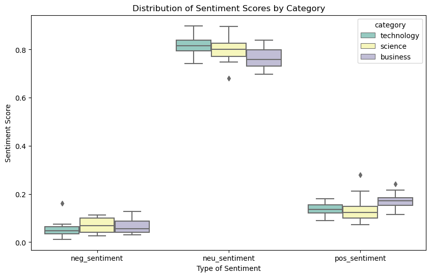

```python
# Select the relevant sentiment score columns
emotion_scores = filtered_other_df[['category', 'neg_sentiment', 'neu_sentiment', 'pos_sentiment']]

emotion_data_long = pd.melt(emotion_scores, id_vars=['category'], value_vars=['neg_sentiment', 'neu_sentiment', 'pos_sentiment'],
                            var_name='Type of Sentiment', value_name='Sentiment Score')
# Plot the boxplot
plt.figure(figsize=(10, 6))
sns.boxplot(x='Type of Sentiment', y='Sentiment Score', hue='category', data=emotion_data_long, palette="Set3")
plt.title('Distribution of Sentiment Scores by Category')
plt.show()
```

## 6 Summary

### 6.1 Conclusions

My project aims to investigate which adjectives used by speakers are persuasive and to conduct a sentiment analysis of the speeches. The specific tasks include:

### Data Analysis:

1. Extracting adjectives from the speeches using the spacy library.
2. Classifying and extracting unique adjectives from each domain.
3. Analyzing sentiment scores for each article, including negative, neutral, positive, and composite scores.
4. Generating word clouds of unique adjectives for different themes (Technology, Science, Business).

### Feature Generation:

Based on the processed data, further analyzing and extracting relevant features for deeper understanding and further research.

### 6.2 Summary of Prepared Data

```python
final_df.columns
```

```
Index(['link', 'title', 'description', 'Related Topics', 'Year', 'subtitles',
       'tokenized_subtitles', 'word_count', 'subtitles_without_stopwords',
       'lemmatized_subtitles', 'category', 'neg_sentiment', 'neu_sentiment',
       'pos_sentiment', 'compound_sentiment'],
      dtype='object')
```

The final_df provides a comprehensive view of the TED Talks data along with sentiment analysis results:

- **link, title, description**: Used primarily for identifying different talks.
- **Related Topics**: Analyzed to determine common themes across different talks and categories.
- **lemmatized_subtitles**: Used for more accurate text analysis.
- **category**: Categorizing talks into technology, science, and business.
- **neg_sentiment, neu_sentiment, pos_sentiment, compound_sentiment**: Sentiment scores.

```python
filtered_adjectives_df.columns
```

```
Index(['category', 'filtered_adjectives'], dtype='object')
```

- **category**: Identifies the category (technology, science, business) to which the adjectives belong.
- **filtered_adjectives**: Lists of unique adjectives used in TED Talks for each category, used for generating word clouds.

# 7 References and Resources

## 7.1 References

[1] Ebaid, H. A. (2018). Adjectives as Persuasive Tools: The Case of Product Naming. Open Journal of Modern Linguistics, 8, 262-293.

[2] Heng, L. Z., Hoon, G. K., & Samsudin, N. H. (2020). Words Of Persuasion: Best Adjectives For Persuasive Ted Talks. In N. Baba Rahim (Ed.), Multidisciplinary Research as Agent of Change for Industrial Revolution 4.0, vol 81. European Proceedings of Social and Behavioural Sciences (pp. 450-460). European Publisher. https://doi.org/10.15405/epsbs.2020.03.03.53

[3] The most popular TED Talks of 2023. https://www.ted.com/playlists/839/

[4] The most popular TED Talks of all time. https://www.ted.com/playlists/171/the_most_popular_ted_talks_of_all_time

## 7.2 Resources used

Beautiful Soup: Build a Web Scraper With Python [Online]. Available: https://realpython.com/beautiful-soup-web-scraper-python/

Selenium Tutoria [Online]. Available: https://www.selenium.dev/documentation/webdriver/

Python Selenium Tutorial - Automate Websites and Create Bots [Online]. Available: https://www.youtube.com/watch?v=NB8OceGZGjA

Natural Language Processing With spaCy in Python https://realpython.com/natural-language-processing-spacy-python/ [Online]. Available:

SpaCy Package - Text Analysis - Guides at Penn Libraries [Online]. Available: https://guides.library.upenn.edu/penntdm/python/spacy

NLTK :: Natural Language Toolkit [Online]. Available: https://www.nltk.org/

Natural Language Processing With Python's NLTK Package [Online]. Available: https://realpython.com/nltk-nlp-python/

Seaborn [Online]. Available: https://www.w3schools.com/python/numpy/numpy_random_seaborn.asp

seaborn.heatmap [Online]. Available: https://seaborn.pydata.org/generated/seaborn.heatmap.html

Beginners Guide - How to Configure a Heatmap Visualization | Grafana [Online]. Available: https://www.youtube.com/watch?v=SGWBzQ54koE